# Predicting Online Sales from Webpage Analytics

Lesley Miller, Cheng Min, Shivam Verma

# Project Summary

> Here we attempt to build a classification model using the light gradient boosting algorithm which can use webpage metrics from a given online shopping website to predict whether the final action of a new customer is purchasing (i.e., Revenue is TRUE) or not (i.e., Revenue is FALSE). Our final classifier performed well on an unseen test data set, with the F1 score of 0.646 and the test accuray calculated to be 90.9%. The precision and recall of our classifier on the test set are 0.699 and 0.6 respectively. Due to substantially high number of false positives & negatives, we recommend further iteration to improve this model.

# Introduction

> Online shopping has rapidly become a dominant player in commerce. It’s [been reported](https://optinmonster.com/online-shopping-statistics/) that within the next 3 years, 91% of those in the United States will have shopped online! That is nearly 300 million people for the US alone. Additionally, in 2020 it is [predicted](https://optinmonster.com/online-shopping-statistics/) that 4 trillion dollars will be spent by online shoppers. Given this enormous potential, online retailers will want to know reliable ways to predict user behavior and uncover insight into what factors are most predictive of sales. The following analysis builds a binary classifier to predict a sale coded as `TRUE` or no sale coded as `FALSE`. In addition, we report the top 10 most important features associated with making a prediction.

# Methods

## Data Source

> The data set used in this project is of online shopping webpage metrics created by C. Okan Sakar, S. Olcay Polat, Mete Katircioglu & Yomi Kastro(Sakar et al. 2019). It was sourced from the UCI Machine Learning Repository (Dua and Graff 2019) and can be found [here](https://archive.ics.uci.edu/ml/datasets/Online+Shoppers+Purchasing+Intention+Dataset). Each row in the data set represents webpage metrics on a single shopper which was extracted from the URL information and includes the final action (purchase or not) and several other measurements (e.g., Number of Distinct Product Related pages, Time spent on Product Related pages, closeness of site visitng time to a special day, etc.).

## Exploratory Data Analysis

### Brief Data Summary

[Data Source Here](https://archive.ics.uci.edu/ml/datasets/Online+Shoppers+Purchasing+Intention+Dataset)

> - Each row represents a session by a single user.
> - Each user has only 1 session in the dataset.
> - The data is for a 1-year period.
> - ~15% of sessions result in a purchase.
> - Predictive variables included in this analysis are user’s visit information, web analytics features & geographic features. See data description table for more details about each variable used in the model.

### Description of the Variables

[See Appendix Here](https://ubc-mds.github.io/DSCI522_309/doc/Appendix.html)

### Categorical Variables

> The dataset consists of 8 categorical variables that can be visualized in the multi-panel plot below. The plot visually describes the distributions of these 8 features in both the `TRUE` or sales case and the `FALSE` or no sales case. It highlights how several variables are quite skewed. For example, there is clearly one browser that dominates all the others regardless if there is a sale or not. The months of March, May and November constitute a substantial share of the dataset. Also with different operating systems, 4 are the most frequently used while the other 4 are under represented. Please note that we have no specific information related to the meaning of categories for the variables `Browser`, `OperatingSystems` & `TrafficType`.

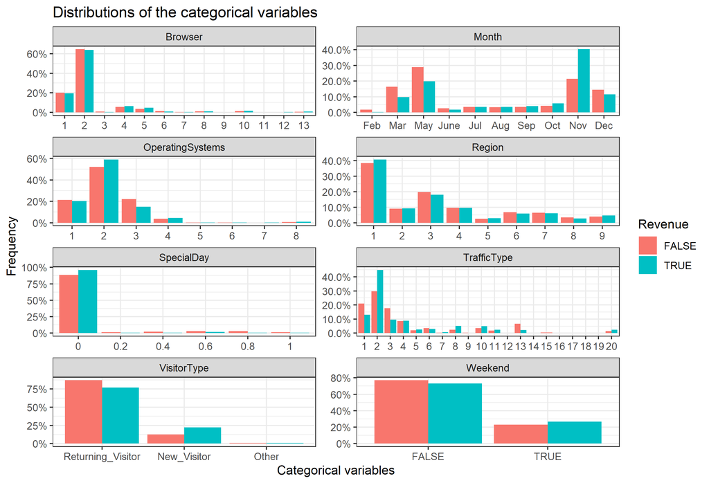

Figure 1, Distribution of Categorical Predictors

### Continuous Variables

> The panels of violin plots below show the distributions of the 7 continuous variables in the dataset. All the variables are highly right skewed, so it is difficult to see the bulk of the distribution since the high outliers are so overpowering in every plot except `ExitRates`. The distributions of these variables between sales and no sales appear to overlap. This may lead to difficulty in distinguishing between the sales and no sales.

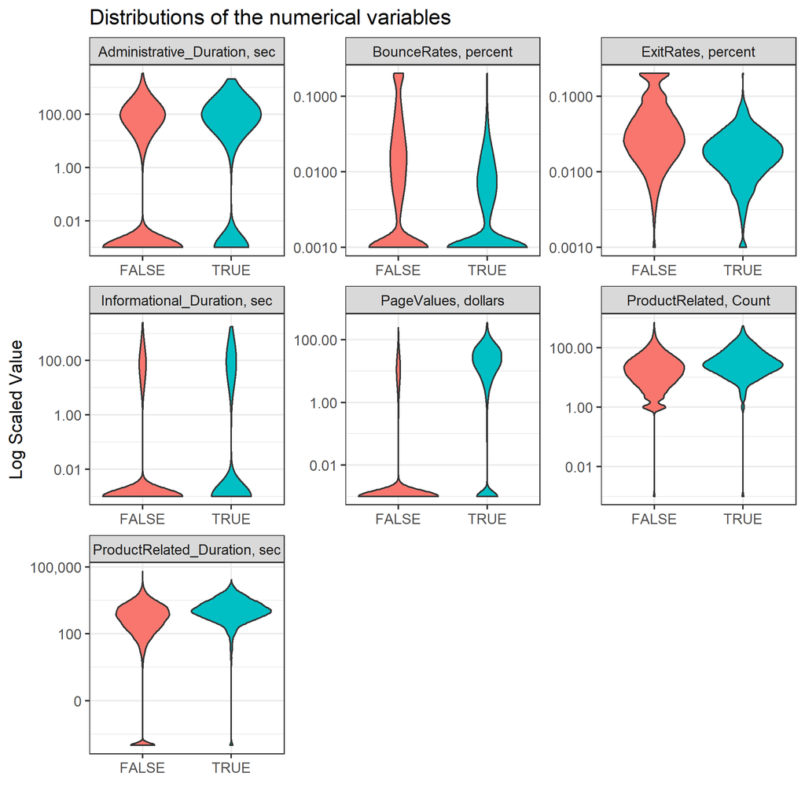

Figure 2, Distribution of Continuous Predictors

### Correlation Matrix

> The heatmap below displays the correlation between the outcome, `Revenue`, and all the predictor variables. The most positively correlated are dark blue while the negatively correlated variables are progressively lighter blue. In addition, it shows the correlations between each of the predictors. Strong correlations can be observed between `Revenue` & `PageValues` and between page count & duration of pages. Several variables are either not correlated or only weakly correlated. But others ariables, like the page type `Administrative` is strongly correlated with the the time spent on the `Administrative` page coded as `Administrative_Duration`. This is also true of the other page types, `Informational` and `Product Related`. These too, are highly correlated with the time spent on them which intuitively makes sense. `PageValues` which is the average dollar value of the page, is the most positively correlated with `Revenue`; while `Exit Rates` and `Bounce Rates` have slight negative correlation with `Revenue`.

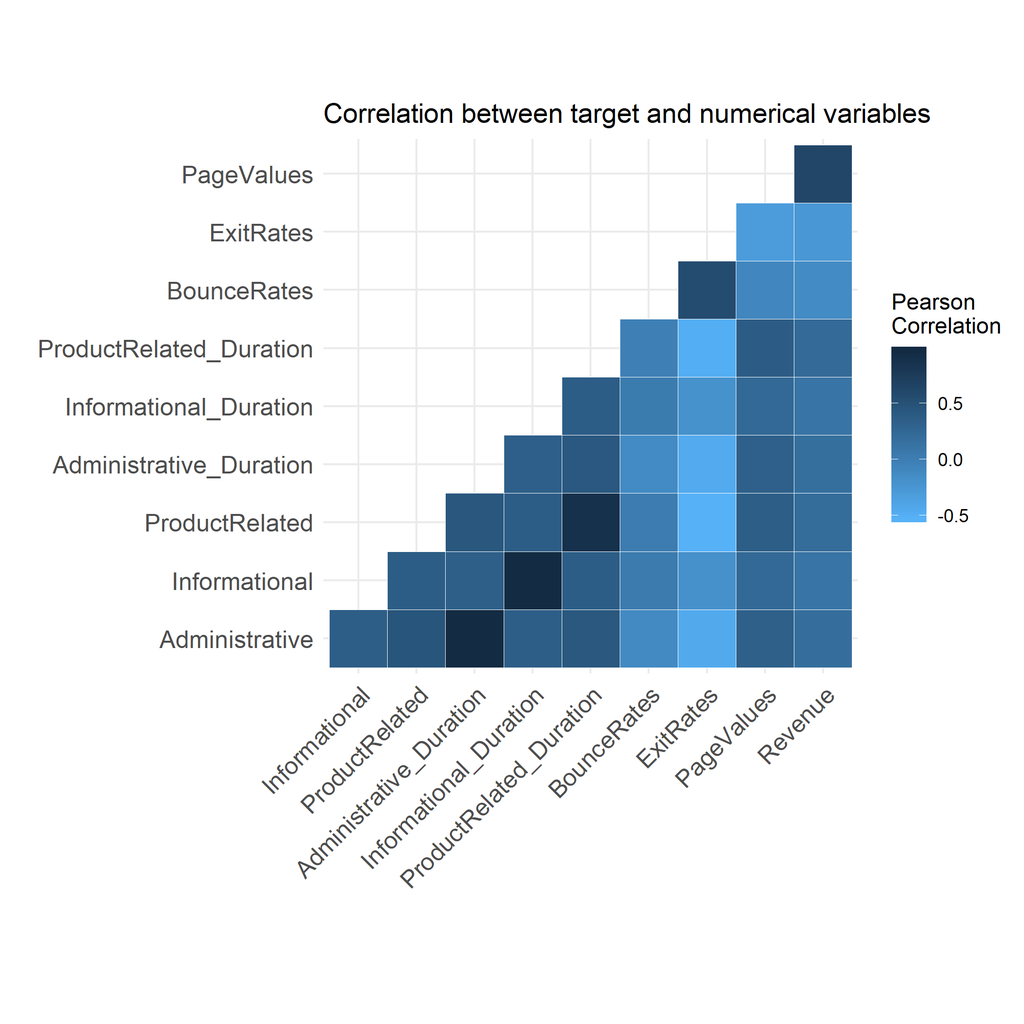

Figure 3, Correlation Matrix

## Modelling

> Here we attempted to build a binary classifer that would predict whether an online shopper made a purchase or not. Since this is a classification problem we tried Machine Learning models that are good for classification and tested their accuracy by optimizing the hyperparameters. We mainly tried Python (Van Rossum and Drake 2009)’s Scikit Learn’s (Pedregosa et al. 2011) [Logistic Regression](https://scikit-learn.org/stable/modules/generated/sklearn.linear_model.LogisticRegression.html), [Random Forest](https://scikit-learn.org/stable/modules/generated/sklearn.ensemble.RandomForestClassifier.html) & [Light Gradient Boosting](https://lightgbm.readthedocs.io/en/latest/Python-Intro.html). The best accuracy on the validation data was achieved by `LGBM`, therefore we went ahead with automating the entire analysis using `LGBM` only.

> We conducted our Exploratory Data Analysis (EDA), in R (R Core Team 2019) and found that the customers who made an online purchase were a small fraction of all the users, ~$15$%). Due to this, there was a possibility of facing the class imbalance issue. To address the potential class imbalance, we included the oversampling strategy (`None`: No oversampling and `balanced`: automatically balancing the weights inversely propotional to the class frequencies) provided by `LGBM` in our hyper-parameter optimization and the modeling framework to automatically decide the most optimal oversampling strategy.

> From the initial EDA, we also saw that the variables had a highly skewed distribution with many outliers. Due to this challenge, we preprocessed the data using [Quantile Transformation](https://scikit-learn.org/stable/modules/generated/sklearn.preprocessing.QuantileTransformer.html) provided by Scikit Learn. This method transforms the individual explanatory variables to follow a normal distribution. This transformation is a robust preprocessing technique and reduces the impact of outliers present in the data.

#### Analysis Packages

Both R (R Core Team 2019) and Python (Van Rossum and Drake 2009) were used throughout this project along with the following R and Python packages: docopt for python (Keleshev 2014), tidyverse (Wickham 2017), knitr (Xie 2014), here (Müller 2017), carat (Kuhn 2020), gridExtra (Auguie 2017), docopt for R (de Jonge 2018), numpy (Oliphant 2006), scikit-learn (Pedregosa et al. 2011), data.table (Dowle and Srinivasan 2019), plotly (Sievert 2018), cowplot (Wilke 2019) and scales (Wickham 2018).

# Results

## Hyperparameters and Feature Importance

Best Hyperparameters

[output not shown]

> **Feature Importance**: A question of interest for an online retailer might be which variables are most strongly associated with predicting a sale or not. The plot below displays the top ten most important features for making a prediction. The top predictors include `ExitRate` which intuitively makes some sense. This variable is related to how fast a shopper is leaving the website and so it follows that it would have a strong association with classifying sales. The other important predictors include `ProductRealted_Duration` which has to do with how long a shopper spent on a product related page and `ProductRelated` variable which measures the number of product related pages the user visited while on the site.

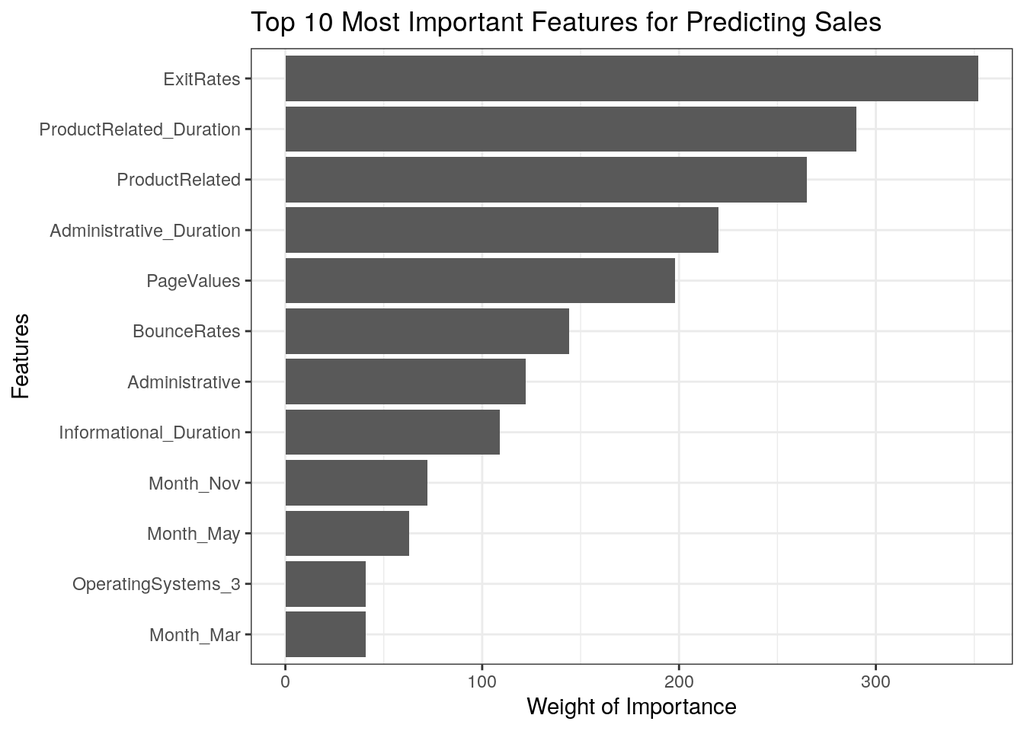

Figure 4, Feature Importance

## Model Performance

> We used the confusion matrix, precision, recall, F1, and ROC curve, to evaluate the performance of our model.

> **Confusion Matrix**: Based on the chosen threshold this matrix highlights the classification (True Positives & True Negatives) & misclassifications (False Positives & False Negatives) made by the model. The threshold is automatically chosen by the model based on maximizing the F1-Score. By looking at the confusion matrix we can know the precision, recall & F1-Score of the predictions which gives a holistic view of the performance of the model.

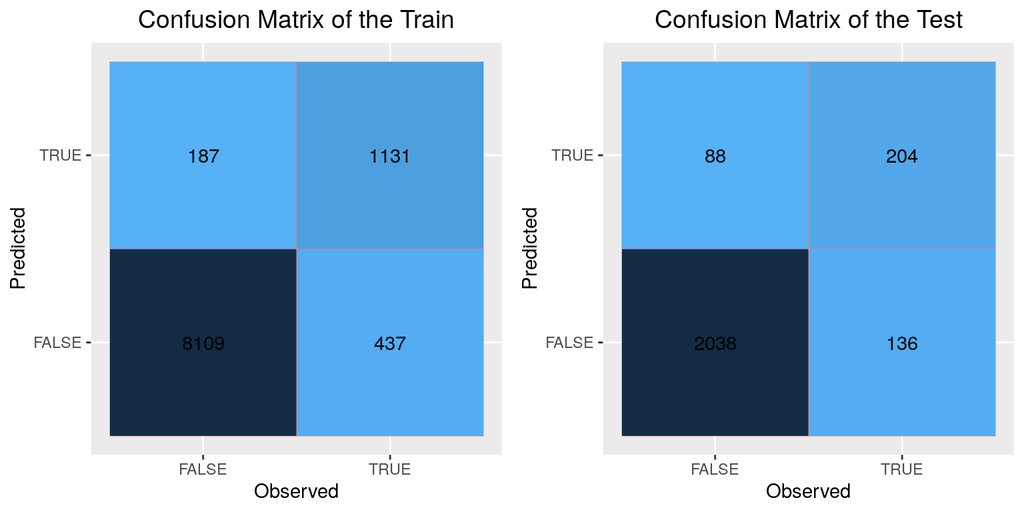

Figure 5, Confusion Matrix

> **Precision & Recall**: The model metrics table below details the performance of the model when classifying a sale or no sale on both the training and the testing data. For the training data, the precision of the model is more than ~85%. The recall is quite a bit lower with the model able to identify around 70% of the true sales. For testing data these corresponding scores are even lower. On the test set, out of the all the predicted sales, more than 65% were correctly identified; and out of the all the true sales the model could only identify ~ 60%.

Model Evaluation Metrics on Train and Test Data

| Dataset | Precision | Recall | F1_Score |
| --- | --- | --- | --- |
| Train | 0.858 | 0.721 | 0.784 |
| Test | 0.699 | 0.600 | 0.646 |

> **ROC-AUC Curve**: Area Under the ROC curve is an apt measure of model performance because it doesn’t depend on the threshold chosen for classifying the predicted class.

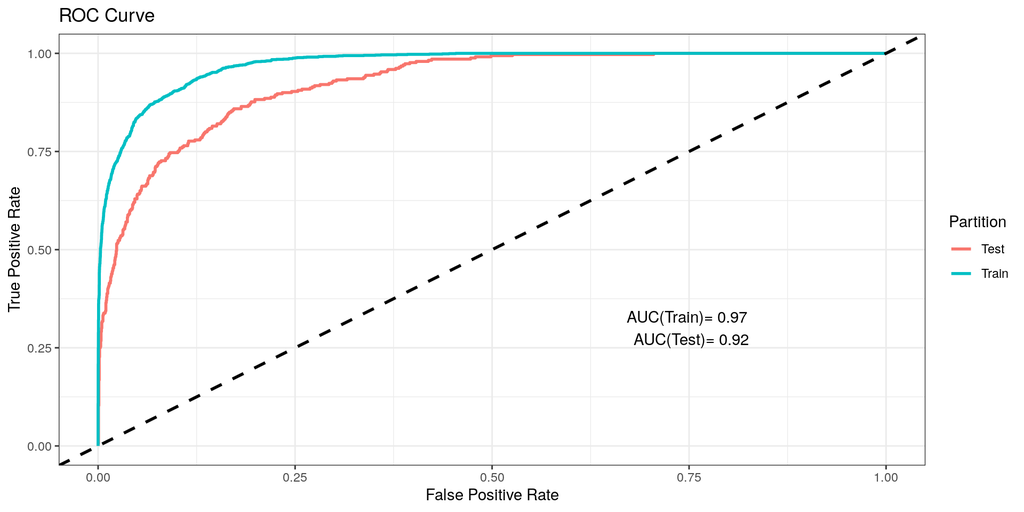

Figure 6, ROC-AUC Curve

## Choosing an Optimal Threshold

> **Effect of Threshold on Performance**: As evidenced by ROC curve in Fig. 6, an online retailer may want to manually adjust the threshold for determining if an observation is classifed as a `SALE`. The decision for an optimal threshold is highly dependent on whether a retailer cares more about the precision or recall of the model. Our model optimizes the F1 score which is a balance of the precision and recall and can be seen as the point in Figure 7 where all three curves meet. However, an online retailer may prefer to have a more precise model and will thus decrease the recall. Or a retailer may prefer to have a high recall system which then reduces the precision of the model. Figure 7 illustrates how a retailer may want to adjust the the model threshold in order to optimize their business objectives.

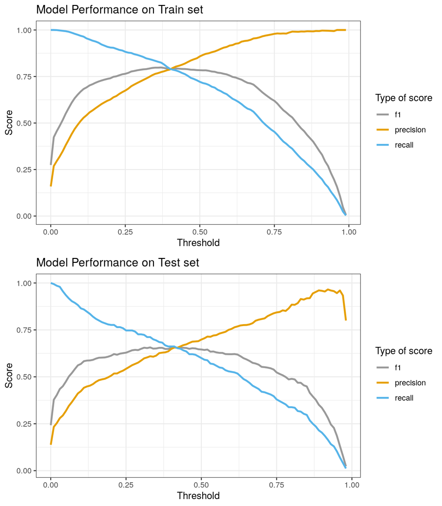

Figure 7, Optimal Threshold

# Limitations

> This dataset contained only ~15% of the class of interest, namely online sales. Such a low proportion of sales examples in the data may be contributing to the low precision and recall on the test set. There was also no feature selection performed which may have resulted in a great number of irrelevant features being retained in the model.

# Future Directions

> Future improvements to the model might include performing `Recursive Feature Elimination` to remove features that are least associated with predicting sales.

# References

Auguie, Baptiste. 2017. *GridExtra: Miscellaneous Functions for "Grid" Graphics*. https://CRAN.R-project.org/package=gridExtra.

de Jonge, Edwin. 2018. *Docopt: Command-Line Interface Specification Language*. https://CRAN.R-project.org/package=docopt.

Dowle, Matt, and Arun Srinivasan. 2019. *Data.table: Extension of ‘Data.frame‘*. https://CRAN.R-project.org/package=data.table.

Dua, Dheeru, and Casey Graff. 2019. “UCI Machine Learning Repository.” University of California, Irvine, School of Information; Computer Sciences. http://archive.ics.uci.edu/ml.

Keleshev, Vladimir. 2014. *Docopt: Command-Line Interface Description Language*. https://github.com/docopt/docopt.

Kuhn, Max. 2020. *Caret: Classification and Regression Training*. https://CRAN.R-project.org/package=caret.

Müller, Kirill. 2017. *Here: A Simpler Way to Find Your Files*. https://CRAN.R-project.org/package=here.

Oliphant, Travis E. 2006. *A Guide to Numpy*. Vol. 1. Trelgol Publishing USA.

Pedregosa, F., G. Varoquaux, A. Gramfort, V. Michel, B. Thirion, O. Grisel, M. Blondel, et al. 2011. “Scikit-Learn: Machine Learning in Python.” *Journal of Machine Learning Research* 12: 2825–30.

R Core Team. 2019. *R: A Language and Environment for Statistical Computing*. Vienna, Austria: R Foundation for Statistical Computing. https://www.R-project.org.

Sakar, C Okan, S Olcay Polat, Mete Katircioglu, and Yomi Kastro. 2019. “Real-Time Prediction of Online Shoppers’ Purchasing Intention Using Multilayer Perceptron and Lstm Recurrent Neural Networks.” *Neural Computing and Applications* 31 (10). Springer: 6893–6908.

Sievert, Carson. 2018. *Plotly for R*. https://plotly-r.com.

Van Rossum, Guido, and Fred L. Drake. 2009. *Python 3 Reference Manual*. Scotts Valley, CA: CreateSpace.

Wickham, Hadley. 2017. *Tidyverse: Easily Install and Load the ’Tidyverse’*. https://CRAN.R-project.org/package=tidyverse.

———. 2018. *Scales: Scale Functions for Visualization*. https://CRAN.R-project.org/package=scales.

Wilke, Claus O. 2019. *Cowplot: Streamlined Plot Theme and Plot Annotations for ’Ggplot2’*. https://CRAN.R-project.org/package=cowplot.

Xie, Yihui. 2014. “Knitr: A Comprehensive Tool for Reproducible Research in R.” In *Implementing Reproducible Computational Research*, edited by Victoria Stodden, Friedrich Leisch, and Roger D. Peng. Chapman; Hall/CRC. http://www.crcpress.com/product/isbn/9781466561595.